# Как начать верить элицитации?

Г. Мороз

## Исследования грамматичности

Исследование грамматичности — является центральным хотя и не единственным источником данных в лингвистике (ср. с корпусными, психолингвистическими и нейролингвистическими исследованиями). Лингвисты разработали достаточно большой арсенал экспериментов, позволяющих исследовать грамматичность, которые в основном различаются типом ответов, получаемым от участников:

- бинарная классификация языкового примера
- оценка языкового примера с использованием некоторой дискретной шкалы (шкалы Лайкерта, (Likert 1932))
- оценка языкового примера с использованием некоторой непрерывной шкалы (Magnitude estimation, (Bard, Robertson, and Sorace 1996))
- сравнение двух языковых примеров (минимальные пары)

## Исследования грамматичности

Идея, являющаяся ядром всех экспериментов на грамматичность, описана еще в работе (Galton 1907). В большинстве работ смотрят, что влияет на исседования грамматичности (Dbrowska 2010, Miller et al. (2009), Featherston (2008), Häussler and Juzek (2017), T. S. Juzek (2016)). Также интерес представляет работа (Langsford et al. 2018), посвященная сравнению результатов, полученных разными методами.

## Однако на практике…

[figure not shown]

- экспедиционная элицитация

[interactive chart not shown]

- дополнительные параметры (такие как пол, возраст, усталость информанта и т.п.) просто игнорируются
- необходимо делать сходные выводы о грамматичности предложения исходя из разных тестов
- необходимо инкорпорировать дополнительные параметры в модель

## Грамматичность

- Предположим, что грамматичность предложения — это некоторое значение от 0 (неграмматичное) до 1 (грамматичное).
- Тогда в зависимости от типа эксперимента мы можем моделировать грамматичность (p(+) и p(∗))

## Грамматичность: “можно сказать” и “нельзя сказать”

Представим себе обычную элицитацию, где k (27) из n (83) носителей признали предложение грамматичным.

- Фриквентистский подход: биномиальный тест
- Хакерский подход: симуляция
- Байесовский подход: корректировка априорного бета распределение при помощи данных

## Грамматичность: “можно сказать” и “нельзя сказать”

Фриквентистский подход: биномиальный тест

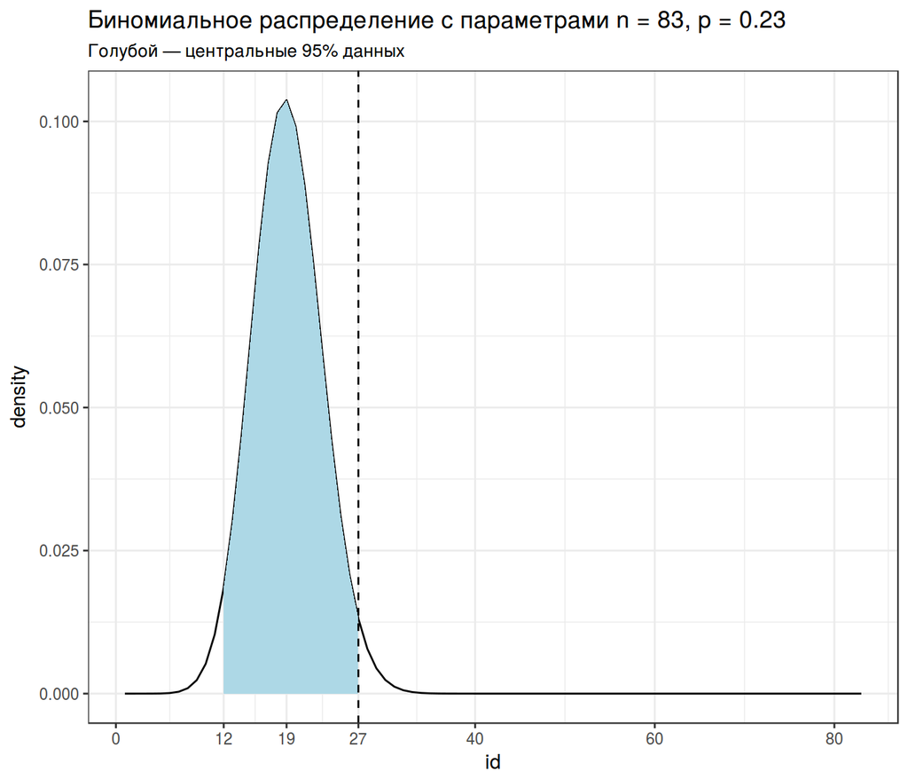

```
##
##
##
## data:  27 out of 83
## number of successes = 27, number of trials = 83, p-value = 0.04936
## alternative hypothesis: true probability of success is not equal to 0.23
## 95 percent confidence interval:
##  0.2264864 0.4369985
## sample estimates:
## probability of success
##              0.3253012
```

## Грамматичность: “можно сказать” и “нельзя сказать”

Хакерский подход: симуляция

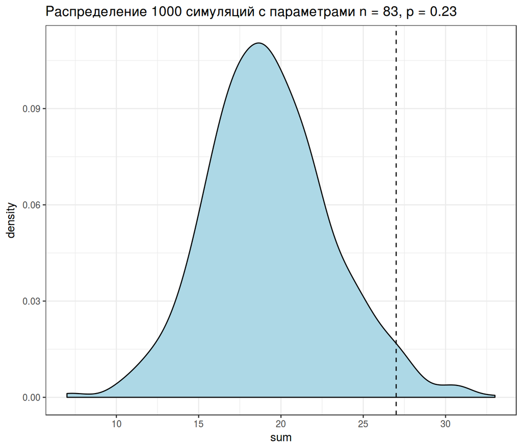

| greater | n |
| --- | --- |
| FALSE | 960 |
| TRUE | 40 |

## Грамматичность: “можно сказать” и “нельзя сказать”

Байесовский подход: корректировка бета распределения.

$$f(x; α, β) = \frac{x^{α-1}\times (1-x)^{β-1}}{B(α, β)}; 0 \leq x \leq 1; α, β > 0$$
Бета функция:
$$Β(α, β) = \frac{Γ(α)\times Γ(β)}{Γ(α+β)} = \frac{(α-1)!(β-1)!}{(α+β-1)!}$$

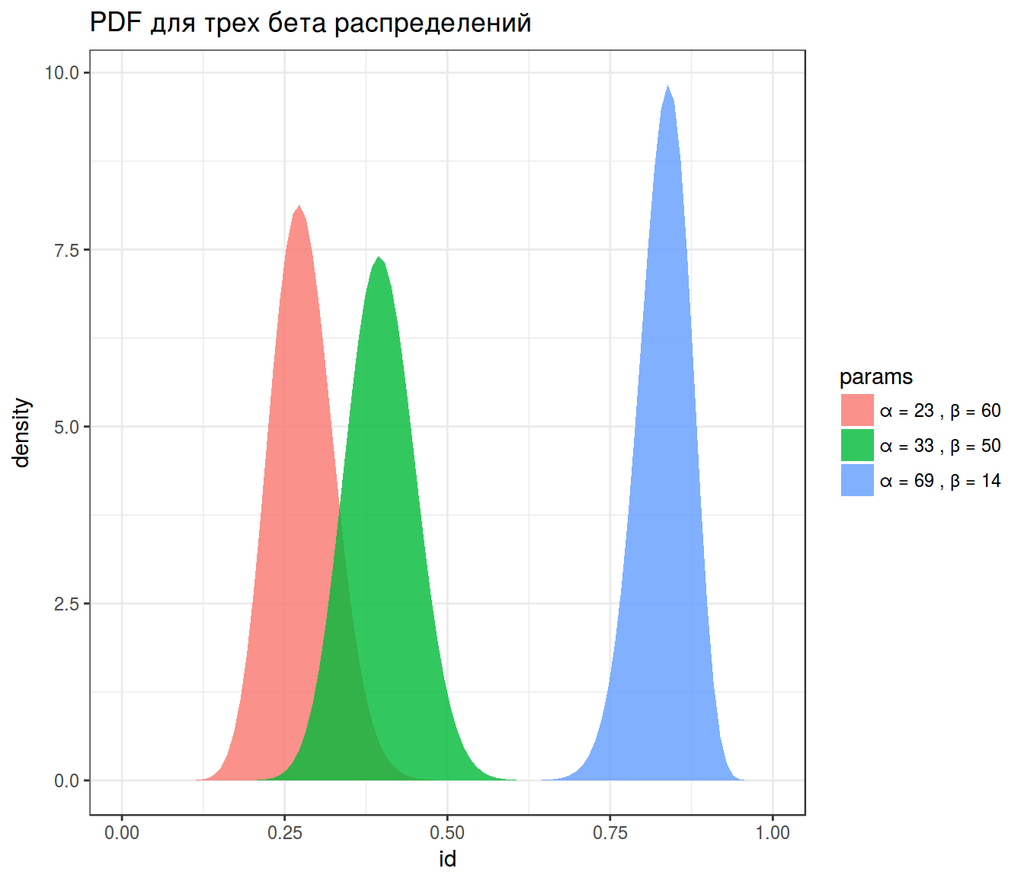

$$Ε[X] = \frac{α}{α+β}; D[X] = \frac{α\times β}{(α+β)^2(α+β+1)}$$

… а тут надо бы разораться с байесовской статистикой…

## Грамматичность: “можно сказать” и “нельзя сказать”

Shiny (пакет на языке R) приложение для сегодняшнего доклада:

```r
shiny::runGitHub("agricolamz/2018_18.04.28_Grammaticality_shiny")
```

## Вариативность

Перед этим мы считали, что ответы носителей бывают двух типов. Но это же неправда!

- “можно так, а можно так…”
- “я так не говорю, но от других слышал(а)”
- носитель может не осознавать свою вариативность…

Обозначим все эти ситуации как p(?)

## Ограничения на p(?)

- для значения грамматичности 1 распределение вероятностей должно быть:
  - $p(∗) = 0,\ p(?) = 0,\ p(+) = 1$
- для значения грамматичности 0 распределение вероятностей должно быть:
  - $p(∗) = 1,\ p(?) = 0,\ p(+) = 0$
- для значения грамматичности 0.5 все ответы должны быть равновероятны:
  - $p(∗) = \frac{1}{3},\ p(?) = \frac{1}{3},\ p(+) = \frac{1}{3}$

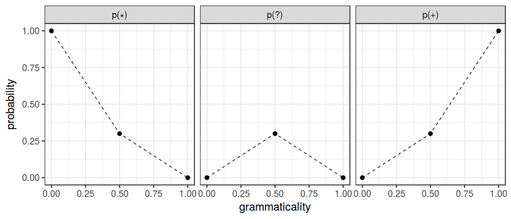

## Распределение Дирихле

Бета распределение:
$$Β(α, β) = \frac{Γ(α)\times Γ(β)}{Γ(α+β)} = \frac{(α-1)!(β-1)!}{(α+β-1)!}$$

[figure not shown]

## Грамматичность: учитывая вариативность

Shiny (пакет на языке R) приложение для сегодняшнего доклада:

```r
shiny::runGitHub("agricolamz/2018_18.04.28_Grammaticality_shiny")
```

## Как же нам получить соответствующее распределение Дирихле?

- Функция правдоподобия и куча других методов

→ можно использовать фриквентистки, оценивая доверительные интервалы и т. п.

→ можно использовать хакерски, симулируя фриквентисткий подход

→ можно использовать байесовски, имея некоторые априорные вероятности

## Заключение

- грамматичность можно оценивать на шкале отличной от бинарный грамматичный vs. неграмматичный
- используя бета распределения и распределения дирихле, мы можем сравнивать грамматичность разных предложений, и визуализировать степень доверия к разным данным
- больше носителей, больше примеров, подтверждающих какое-то явление…

Презентация доступна здесь: https://goo.gl/CMbjA2

Приложение доступно здесь: https://goo.gl/pqhMgk

Пишите мне: agricolamz@gmail.com

## Referenses

Bard, Ellen Gurman, Dan Robertson, and Antonella Sorace. 1996. “Magnitude Estimation of Linguistic Acceptability.” *Language*. JSTOR, 32–68.

Dbrowska, Ewa. 2010. “Naive V. Expert Intuitions: An Empirical Study of Acceptability Judgments.” *The Linguistic Review* 27 (1). Walter de Gruyter GmbH & Co. KG: 1–23.

Featherston, Sam. 2008. “Thermometer Judgments as Linguistic Evidence.” *Was Ist Linguistische Evidenz*, 69–89.

Galton, Francis. 1907. “Vox Populi (the Wisdom of Crowds).” *Nature* 75 (7): 450–51.

Häussler, Jana, and Tom Juzek. 2017. “Detecting and Discouraging Non-Cooperative Behavior in Online Experiments Using an Acceptability Judgment Task1.” In *A Blend of Malt: Selected Contributions from the Methods and Linguistic Theories Symposium 2015*, 15:73. University of Bamberg Press.

Juzek, Thomas Stephan. 2016. “Acceptability Judgement Tasks and Grammatical Theory.” PhD thesis, University of Oxford.

Langsford, Steven, Amy Perfors, Andrew T Hendrickson, Lauren A Kennedy, and Danielle J Navarro. 2018. “Quantifying Sentence Acceptability Measures: Reliability, Bias, and Variability.” *Glossa: A Journal of General Linguistics* 3 (1). Ubiquity Press.

Likert, Rensis. 1932. “A Technique for the Measurement of Attitudes.” *Archives of Psychology*.

Miller, Brent, Pernille Hemmer, Mark Steyvers, and Michael D Lee. 2009. “The Wisdom of Crowds in Rank Ordering Problems.” In *9th International Conference on Cognitive Modeling*.